# Laboratorio: Planificación STRIPS

Richard Camilo Saavedra Coneo

24/6/2020

### 1. Descripción de la actividad:

Expresa el siguiente escenario en la representación tipo STRIPS:

En una habitación hay un mono, una caja y un plátano, tal como indica la figura (situación inicial). El objetivo del mono es tener el plátano. El mono puede:

- Ir de una posición a otra.
- Empujar la caja de una posición a otra si está en la misma posición que ella no está sobre ella.
- Subirse a la caja si está en la misma posición que ella.
- Coger el plátano si está en encima de la caja.

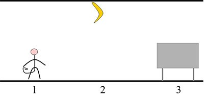

Imagen Representación

Modelar en PDDL (dominio.pddl y problema[S].pddl - 3 problemas) el mismo escenario que se plantea en la actividad y resolver los problemas con 3 planificadores del estado del arte.

### 2. Desarrollo:

#### 2.1 Definición del PDDL

PDDL esta compuesta por dos partes: la definición del dominio y la definición del problema(instancia)

##### 2.1.1 Definición del dominio

###### Nombre del dominio:

Inicialmente establecemos el nombre del dominio “Banana” :

`(define (domain banana)`

###### Requerimientos:

:strips - Aun que en pruebas con el planificador inicial no afecta su funcionamiento configuramos el subconjunto más básico de PDDL :strips.

:typing - Me permite específicar tipos de objetos específicos.

:negative-preconditions - La herramienta utilizada recomienda que configuremos precondiciones negativas. Al no colocarlo presentaba la alerta pero corria el planificador

`(:requirements :strips :typing :negative-preconditions )`

###### Tipos:

```
(:types
    mono caja posicion banana
)
```